# How severe weather events impact to US

Stefano Galeano

31 marzo 2017

## Synopsis

This analysis involves the use of the U.S. National Oceanic and Atmospheric Administration’s (NOAA) storm database in order to show the impact of the atmospheric events in US.

The purposse of the analysis is to answer the following question:

1. Across the United States, which types of events are most harmful with respect to population health?
2. Across the United States, which types of events have the greatest economic consequences?

The analysis is performed with the following steps:

1. Import library
2. Data Processing: Loading Data, Conversion and Trasformation Data
3. Plots
4. Results

## Import library

```r
library(reshape2)
```

## Data Processing

### Loading Data

Firstly, the data is loaded into R from the source https://d396qusza40orc.cloudfront.net/repdata%2Fdata%2FStormData.csv.bz2. This process is a time-consuming operation, so it is used the `cache = TRUE`. The dataset contains 37 different field, and only some of them are usefull for our purpose.

The fields loaded are:

- `EVTYPE`: event type (tornado, heat, ..)
- `FATALITIES`: number of fatalities
- `INJURIES`: number of injuries
- `PROPDMG`: property damage `[$]`
- `PROPDMGEXP`: property damage exponential factor. They are considered only `K` (thousand), `M` (milion) and `B` (bilion)

```r
url <- "https://d396qusza40orc.cloudfront.net/repdata%2Fdata%2FStormData.csv.bz2"
filename <- "weatherUS.csv.bz2"


if (!file.exists(filename)){
        download.file(url,filename)
}
if (!exists("weatherUS")){
  weatherUS <- read.csv(filename,colClasses = c(rep("NULL",7),#skip 7 fields
                                                "factor",#EVTYPE
                                                rep("NULL",14),#skip 14 fields
                                                "numeric",#FATALITIES
                                                "numeric",#INJURIES
                                                "numeric",#PROPDMG
                                                "character",#PROPDMGEXP
                                                rep("NULL",11)#skip 11 fields
                                                )
                        )
}
```

### Conversion

It is made a conversion of property damage using the exponential factors. The `PROPDMGEXP` entries which contain values different from number will introduce `NA`. This entries are ignored for this analysis.

```r
weatherUS$PROPDMGEXP <- gsub(pattern = "K|k",replacement = "1000",x = weatherUS$PROPDMGEXP)
weatherUS$PROPDMGEXP <- gsub(pattern = "M|m",replacement = "1000000",x = weatherUS$PROPDMGEXP)
weatherUS$PROPDMGEXP <- gsub(pattern = "B|b",replacement = "1000000000",x = weatherUS$PROPDMGEXP)

weatherUS$PROPDMGTOT <- (weatherUS$PROPDMG * as.numeric(weatherUS$PROPDMGEXP))
```

### Tranformation data

First of all, it is created a list of dataframe, one for each event type of the `EVTYPE` field Using the `split()` function. For each of this event it is calculated the total number of fatalities/injuries and the total property damage`[B$]`. These lists are ordered in order to answer to the question of the analysis.

```r
weatherUSEvent <- split(x = weatherUS,f = weatherUS$EVTYPE)

fatalities <- sapply(X = weatherUSEvent,FUN = function(x){sum(x$FATALITIES)})
injuries <- sapply(X = weatherUSEvent,FUN = function(x){sum(x$INJURIES)})
propDamage <- sapply(X = weatherUSEvent,FUN = function(x){sum(x$PROPDMGTOT,na.rm = TRUE)}) / 1000000000

fatalities <- fatalities[order(fatalities,decreasing = TRUE)]
injuries <- injuries[order(injuries,decreasing = TRUE)]
propDamage <- propDamage[order(propDamage,decreasing = TRUE)]
```

### Plots

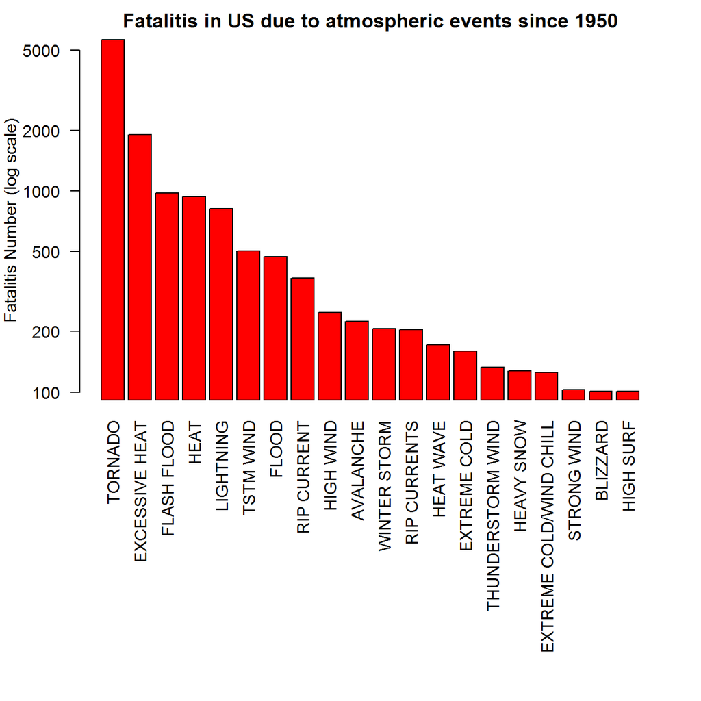

```r
par(mar = c(15,4,2,2))
barplot(fatalities[1:20],
        main = "Fatalitis in US due to atmospheric events since 1950",
        ylab = "Fatalitis Number (log scale)",
        col = "red",
        log="y",
        las=2)
```

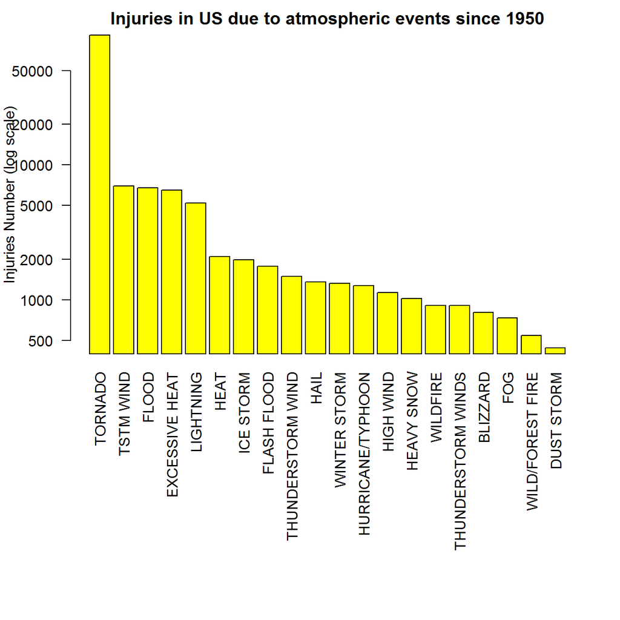

```r
par(mar = c(15,4,2,2))
barplot(injuries[1:20],
        main = "Injuries in US due to atmospheric events since 1950",
        ylab = "Injuries Number (log scale)",
        col = "yellow",
        log="y",
        las=2)
```

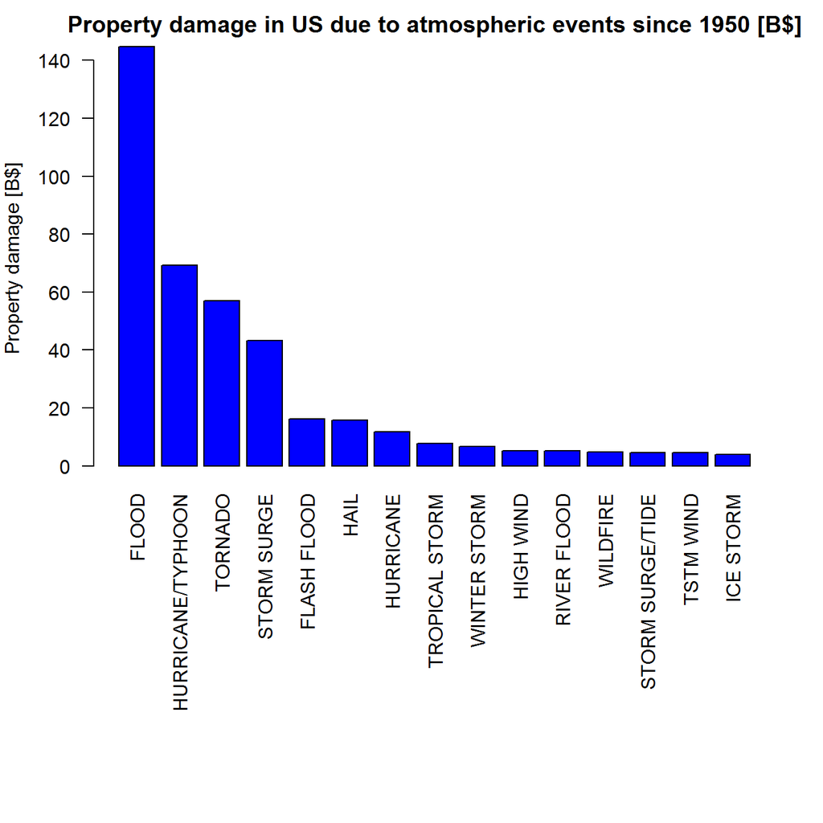

```r
par(mar = c(15,4,2,2))
barplot(propDamage[1:15],
        main = "Property damage in US due to atmospheric events since 1950 [B$]",
        ylab = "Property damage [B$]",
        col = "blue",
        las=2)
```

## Results

### Across the United States, which types of events are most harmful with respect to population health?

As it can be seen from the first two plots, the Tornados are the most harmful. These are the results:

- Number of fatalities: 5633
- Numbero of injuries: 91346

### Across the United States, which types of events have the greatest economic consequences?

As it can be seen from the third plot, the floods have the greatest economic consequences. These are the results:

- Property damage: 144.6577098 Bilion Dollars